# R Notebook

```r
if (require("pacman")) {
    library(pacman)
  }else{
    install.packages("pacman")
    library(pacman)
  }
  pacman::p_load(tidyverse)
```

# Implementing Page Rank Methods

## Example Graph

Consider the following Graph taken from the paper:

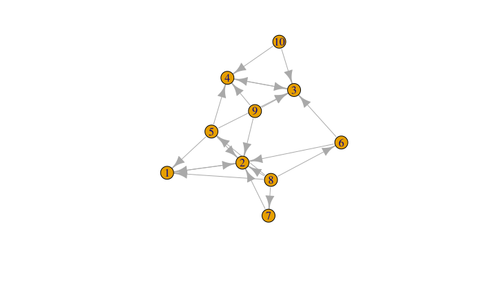

```r
g1 <- igraph::graph.formula(1++2, 1+-8, 1+-5, 2+-5, 2+-7, 2+-8, 2+-6, 2+-9, 3++4, 3+-5, 3+-6, 3+-9, 3+-10, 4+-9, 4+-10, 4+-5, 5+-8, 6+-8, 7+-8)
plot(g1)
```

### Adjacency Matrix

The adjacency Matrix is given by:

```r
A <- igraph::get.adjacency(g1, names = TRUE, sparse = FALSE) %>%
  as.matrix()

## Adjust the Order
(A <- A[order(as.integer(row.names(A))), order(as.integer(colnames(A)))])
```

```
   1 2 3 4 5 6 7 8 9 10
1  0 1 0 0 0 0 0 0 0  0
2  1 0 0 0 0 0 0 0 0  0
3  0 0 0 1 0 0 0 0 0  0
4  0 0 1 0 0 0 0 0 0  0
5  1 1 1 1 0 0 0 0 0  0
6  0 1 1 0 0 0 0 0 0  0
7  0 1 0 0 0 0 0 0 0  0
8  1 1 0 0 1 1 1 0 0  0
9  0 1 1 1 0 0 0 0 0  0
10 0 0 1 1 0 0 0 0 0  0
```

### State Distribution

The state distribution is the transpose of the adjacency matrix:

```r
(p0 <- t(A))
```

```
   1 2 3 4 5 6 7 8 9 10
1  0 1 0 0 1 0 0 1 0  0
2  1 0 0 0 1 1 1 1 1  0
3  0 0 0 1 1 1 0 0 1  1
4  0 0 1 0 1 0 0 0 1  1
5  0 0 0 0 0 0 0 1 0  0
6  0 0 0 0 0 0 0 1 0  0
7  0 0 0 0 0 0 0 1 0  0
8  0 0 0 0 0 0 0 0 0  0
9  0 0 0 0 0 0 0 0 0  0
10 0 0 0 0 0 0 0 0 0  0
```

### Probability Transition Matrix

The probability transition matrix is such that each column of the initial state distribution (i.e. the transposed adjacency matrix) is scaled to 1.

```r
p0 %*% diag(1/colSums(p0))
```

```
   [,1] [,2] [,3] [,4] [,5] [,6] [,7] [,8]      [,9] [,10]
1     0    1    0    0 0.25  0.0    0  0.2 0.0000000   0.0
2     1    0    0    0 0.25  0.5    1  0.2 0.3333333   0.0
3     0    0    0    1 0.25  0.5    0  0.0 0.3333333   0.5
4     0    0    1    0 0.25  0.0    0  0.0 0.3333333   0.5
5     0    0    0    0 0.00  0.0    0  0.2 0.0000000   0.0
6     0    0    0    0 0.00  0.0    0  0.2 0.0000000   0.0
7     0    0    0    0 0.00  0.0    0  0.2 0.0000000   0.0
8     0    0    0    0 0.00  0.0    0  0.0 0.0000000   0.0
9     0    0    0    0 0.00  0.0    0  0.0 0.0000000   0.0
10    0    0    0    0 0.00  0.0    0  0.0 0.0000000   0.0
```

#### Create a Function

```r
adj_to_probTrans <- function(adjMat) {
  t(adjMat) %*% diag(1/colSums(t(adjMat)))
}

(T <- adj_to_probTrans(A)) %>% round(2)
```

```
   [,1] [,2] [,3] [,4] [,5] [,6] [,7] [,8] [,9] [,10]
1     0    1    0    0 0.25  0.0    0  0.2 0.00   0.0
2     1    0    0    0 0.25  0.5    1  0.2 0.33   0.0
3     0    0    0    1 0.25  0.5    0  0.0 0.33   0.5
4     0    0    1    0 0.25  0.0    0  0.0 0.33   0.5
5     0    0    0    0 0.00  0.0    0  0.2 0.00   0.0
6     0    0    0    0 0.00  0.0    0  0.2 0.00   0.0
7     0    0    0    0 0.00  0.0    0  0.2 0.00   0.0
8     0    0    0    0 0.00  0.0    0  0.0 0.00   0.0
9     0    0    0    0 0.00  0.0    0  0.0 0.00   0.0
10    0    0    0    0 0.00  0.0    0  0.0 0.00   0.0
```

## Page Rank Random Surfer

The random surfer page rank method modifies the probability transition matrix $T$ so that the method works also for non-ergodic graphs by introducing the possibility of a random jump, we’ll call the surfer transition matrix $S$:

$$\begin{align}
S &= \lambda T + \left( 1- \lambda \right)B :\\
\ \\
B&= \begin{bmatrix}
\frac{1}{N} & \frac{1}{N} & \ldots & \frac{1}{N} \\
\frac{1}{N} & \frac{1}{N} & \ldots & \frac{1}{N} \\
\vdots & \vdots & \ddots & \vdots \\
\frac{1}{N} & \frac{1}{N} & \ldots & \frac{1}{N} \\
\end{bmatrix} \\
N&= \left| \left| V \right| \right| \\
\lambda &\in [0,1]
\end{align}$$

```r
B <- matrix(rep(1/nrow(T), length.out = nrow(T)**2), nrow = nrow(T))
l <- 0.8

S <- l*T+(1-l)*B
```

### Eigen Value Method

The eigenvector corresponding to the the eigenvalue of 1 will be the stationary point:

```r
eigen(S, symmetric = FALSE)
```

```
eigen() decomposition
$values
 [1]  1.000000e+00  8.000000e-01 -8.000000e-01 -8.000000e-01  3.117428e-09 -3.117428e-09  1.233252e-17 -6.831762e-18  1.351981e-18  1.827902e-34

$vectors
             [,1]          [,2]          [,3]          [,4]          [,5]          [,6]          [,7]          [,8]          [,9]         [,10]
 [1,] -0.48531271  5.000000e-01  1.074642e-03  7.070996e-01  6.735753e-01 -6.735753e-01 -2.658112e-01  5.357798e-01 -4.171123e-01  2.122431e-01
 [2,] -0.52732002  5.000000e-01 -1.074642e-03 -7.070996e-01  9.622505e-02 -9.622504e-02  1.896313e-01 -1.330801e-01 -7.334472e-02  1.241240e-01
 [3,] -0.49152601 -5.000000e-01  7.071060e-01  3.197134e-03  9.622505e-02 -9.622504e-02  1.990137e-01 -1.665251e-01  2.591495e-01 -1.598069e-04
 [4,] -0.47977477 -5.000000e-01 -7.071060e-01 -3.197134e-03  2.886751e-01 -2.886751e-01 -3.972519e-02  1.099005e-02 -1.886035e-02  6.690506e-02
 [5,] -0.05288058  7.620569e-17  1.212133e-16 -3.419297e-18 -3.849002e-01  3.849002e-01 -7.585250e-01  5.323206e-01  2.933789e-01 -4.964959e-01
 [6,] -0.05288058  7.620569e-17 -7.099634e-17 -3.419297e-18 -3.849002e-01  3.849002e-01  4.774778e-01 -3.550303e-01  5.560197e-01 -1.341297e-01
 [7,] -0.05288058  7.620569e-17  2.943750e-17 -3.419297e-18 -3.849002e-01  3.849002e-01  2.204565e-01 -5.047228e-01  1.987554e-01  1.561493e-01
 [8,] -0.04558671  6.926804e-17 -1.948070e-18 -4.183296e-17 -7.499367e-09 -7.499367e-09 -1.208463e-16  1.668414e-16 -2.685569e-16  3.416862e-17
 [9,] -0.04558671  6.926804e-17  7.359376e-18 -4.183296e-17 -7.499367e-09 -7.499367e-09 -1.125898e-02  4.013399e-02 -3.989931e-01 -5.316106e-01
[10,] -0.04558671  6.926804e-17  7.359376e-18 -4.183296e-17 -7.499367e-09 -7.499367e-09 -1.125898e-02  4.013399e-02 -3.989931e-01  6.029746e-01
```

So in this case the a stationary point is $\langle -0.49, -0.53, -0.49, -0.48, -0.05, -0.05, -0.05, -0.04, -0.04, -0.04 \rangle$

which can be verified:

$$1 \vec{p} = S\vec{p}$$

```r
(p     <- eigen(S)$values[1] * eigen(S)$vectors[,1])
```

```
 [1] -0.48531271 -0.52732002 -0.49152601 -0.47977477 -0.05288058 -0.05288058 -0.05288058 -0.04558671 -0.04558671 -0.04558671
```

```r
(p_new <- S %*% p)
```

```
          [,1]
1  -0.48531271
2  -0.52732002
3  -0.49152601
4  -0.47977477
5  -0.05288058
6  -0.05288058
7  -0.05288058
8  -0.04558671
9  -0.04558671
10 -0.04558671
```

However this vector does not sum to 1 so the scale should be adjusted (for probabilities the vector should sum to 1):

```r
(p_new <- p_new/sum(p_new))
```

```
        [,1]
1  0.2129185
2  0.2313481
3  0.2156444
4  0.2104889
5  0.0232000
6  0.0232000
7  0.0232000
8  0.0200000
9  0.0200000
10 0.0200000
```

### Power Value Method

Using the power method should give the same result, which it indeed does, but for the scale:

```r
p_new <- p_new *123456789

while (sum(round(p, 9) != round(p_new, 9))) {
    (p     <- p_new)
    (p_new <- S %*% p)
}

p_new
```

[output not shown]

```r
p
```

[output not shown]

This answer is however identical in direction, if it scaled to 1 the same value will be returned:

```r
(p_new <- p_new/sum(p_new))
```

```
        [,1]
1  0.2129185
2  0.2313481
3  0.2156444
4  0.2104889
5  0.0232000
6  0.0232000
7  0.0232000
8  0.0200000
9  0.0200000
10 0.0200000
```

### Scaling

However if the initial state sums to 1, then the scale of the stationary vector will also sum to 1.

```r
p     <- c(1, 0, 0, 0, 0, 0, 0, 0, 0, 0)
p_new <- S %*% p

while (sum(round(p, 9) != round(p_new, 9))) {
    (p     <- p_new)
    (p_new <- S %*% p)
}

cbind(p_new, p)
```

```
        [,1]      [,2]
1  0.2129185 0.2129185
2  0.2313481 0.2313481
3  0.2156444 0.2156444
4  0.2104889 0.2104889
5  0.0232000 0.0232000
6  0.0232000 0.0232000
7  0.0232000 0.0232000
8  0.0200000 0.0200000
9  0.0200000 0.0200000
10 0.0200000 0.0200000
```